# Spotify Analysis

Fawwaz Azrin

2023-08-13

## R Markdown

### Data Cleaning

I loaded the JSON files of the streaming history and append them to a master dataframe. I also read the csv file of the 1 Million song database.

```r
data1 <- fromJSON("StreamingHistory0.json", flatten = T)
data2 <- fromJSON("StreamingHistory1.json", flatten = T)
data3 <- fromJSON("StreamingHistory2.json", flatten = T)
master.data <- rbind(data1,data2,data3)

track.features.data <- read.csv("tracks_features.csv")
```

I introduced another column called `seconds` and obtain the values from `msPlayed`. This represents the number of seconds played of the track.

```r
master.data <- master.data %>%
  mutate(seconds = msPlayed / 1000)
```

For easier analysis, we can convert the `endTime` and `release_date` to a `DateTime` format using POSIXct function.

```r
# Convert character column to POSIXct datetime format
master.data$endTime <- as.POSIXct(master.data$endTime, format = "%Y-%m-%d %H:%M")
track.features.data$release_date <- as.POSIXct(track.features.data$release_date, format = "%Y-%m-%d")
str(track.features.data)
```

Using regex to remove the square brakets and `'` symbol from the artist name in the 1 Million Song dataset.

```r
# Remove brackets and single quotes from the "Text" column
track.features.data$artistName <- gsub("\\['|\\']", "", track.features.data$artists)
```

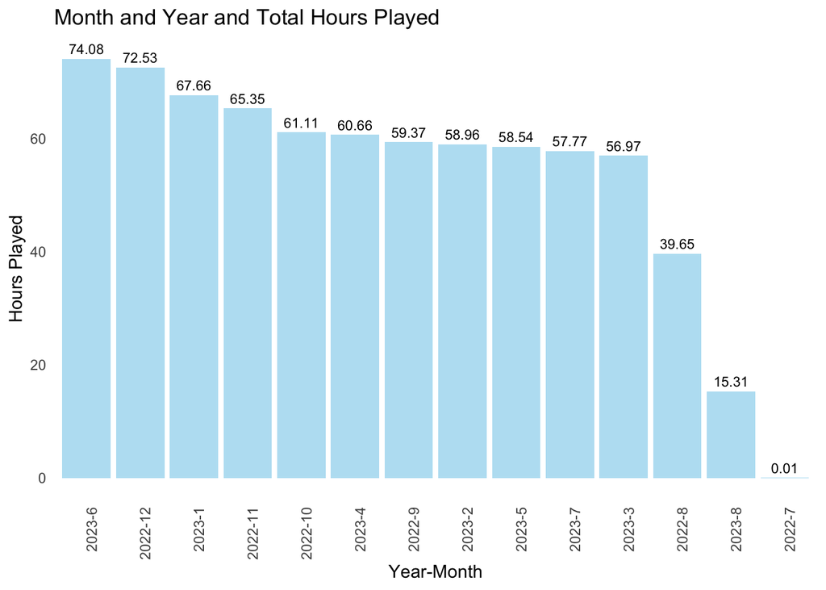

I also want to look at the top 20 tracks that I listened to the most frequent within 2022-2023. Note that for the top 20 we can use the frequency instead of the total hours played to avoid bias with longer tracks.

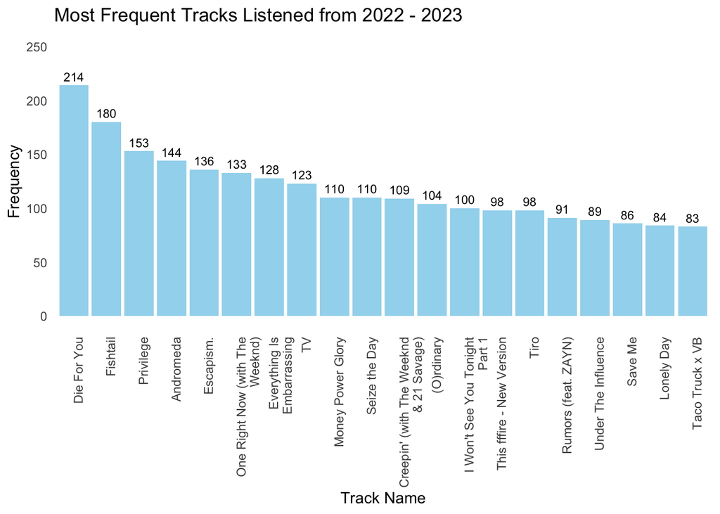

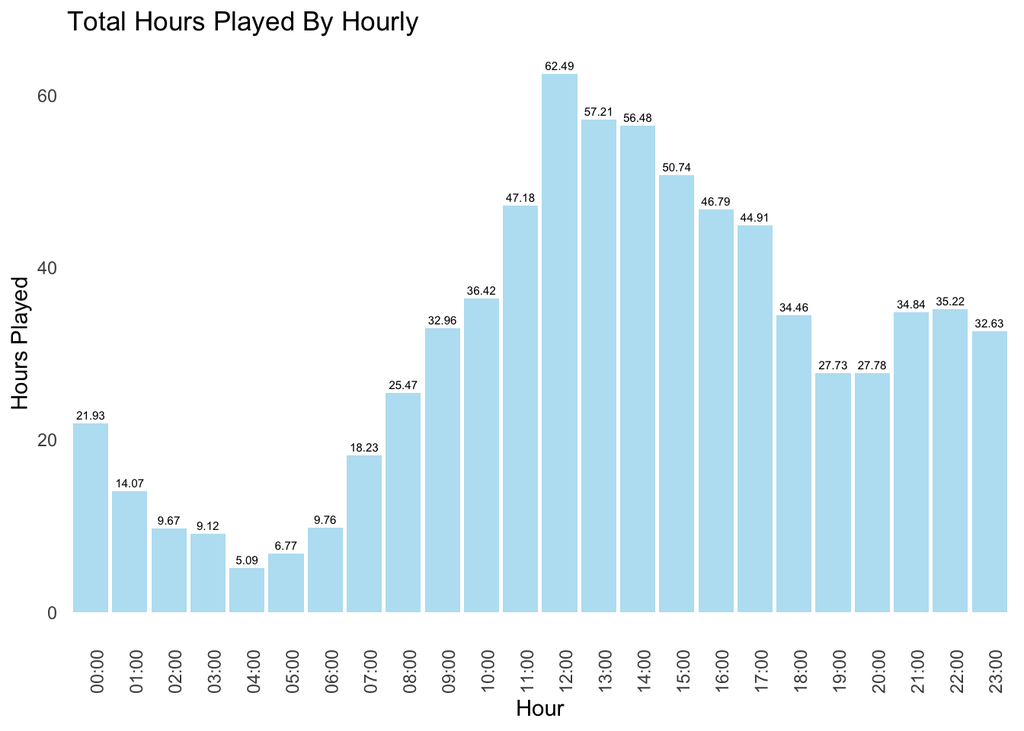

```r
x22 <- master.data %>%
  group_by(hour(endTime)) %>%
  summarise(totalPlayed = sum(seconds)/3600) %>%
  mutate(hour = `hour(endTime)`) %>%
  mutate(hour = paste0(formatC(0:23, width = 2, flag = "0"), ":00")
)

ggplot(x22, aes(x = hour, y = totalPlayed)) + geom_bar(stat = 'identity', alpha = 0.6, fill = 'skyblue') +
  theme_minimal() +
  theme(axis.text.x = element_text(angle = 90, hjust = 1)) +
  labs(x = "Hour", y = "Hours Played", title = "Total Hours Played By Hourly") +
  geom_text(aes(label = round(totalPlayed, 2)), vjust = -0.5, size = 2) +
  theme(panel.grid = element_blank())
```

Due to the difficulties in obtaining the relevant information from the Spotify API calls, we will use an existing dataset obtained from Kaggle to extract those information. The attributes include:

- danceability
- energy
- key
- loudness
- mode
- speechiness
- acousticness
- instrumentalness
- liveness
- valence
- tempo

We will then join these attributes to the song list extracted from the streaming history data and remove any rows that do not have the attributes. This approach will make the clustering easier and less power intensive as we have less amount of data to analyse. However, the data limitation can limit the accuracies and may not provide the best insights on my listening pattern.

After removing the NAs, we will have 871 rows of data.

```r
x22 <- master.data %>%
  group_by(trackName, artistName) %>%
  summarise(freq = n()) %>%
  arrange(-freq)

chosen <- c("danceability", "energy", "key", "loudness", "mode", "speechiness", "acousticness", "instrumentalness", "liveness", "valence", "tempo")

merged_df <- left_join(x22, track.features.data, by = c("trackName" = "name", "artistName"))
merged_df <- merged_df %>%
  select(trackName, artistName, freq, chosen)

# remove duplicates
df <- distinct(merged_df)

unique_df <- df %>%
  distinct(trackName, artistName, .keep_all = TRUE)

# remove NAs
df_no_na <- na.omit(unique_df)
kable(head(df_no_na, 5)) %>%
  kable_styling(latex_options = "striped")
```

| trackName | artistName | freq | danceability | energy | key | loudness | mode | speechiness | acousticness | instrumentalness | liveness | valence | tempo |
| --- | --- | --- | --- | --- | --- | --- | --- | --- | --- | --- | --- | --- | --- |
| Andromeda | Weyes Blood | 144 | 0.467 | 0.461 | 1 | -7.940 | 0 | 0.0274 | 0.368000 | 1.15e-03 | 0.358 | 0.188 | 131.325 |
| I Won’t See You Tonight Part 1 | Avenged Sevenfold | 100 | 0.400 | 0.719 | 7 | -5.109 | 0 | 0.0492 | 0.000451 | 5.81e-03 | 0.218 | 0.101 | 129.505 |
| Under The Influence | Chris Brown | 89 | 0.733 | 0.690 | 9 | -5.529 | 0 | 0.0427 | 0.063500 | 1.20e-06 | 0.105 | 0.310 | 116.992 |
| Lonely Day | System Of A Down | 84 | 0.470 | 0.796 | 8 | -3.277 | 0 | 0.0336 | 0.362000 | 1.10e-06 | 0.133 | 0.215 | 113.108 |
| Chop Suey! | System Of A Down | 76 | 0.419 | 0.934 | 7 | -3.908 | 0 | 0.1200 | 0.000278 | 1.50e-03 | 0.132 | 0.286 | 127.288 |

And I will also change the `key` column to factor

```r
df_no_na$key <- as.factor(df_no_na$key)
```

## Data Exploratory

### Glossary

- **Acousticness**: Numerical, Confidence measure from 0.0 to 1.0 of whether the track is acoustic. 1.0 represents high confidence the track is acoustic.
- **Danceability**: Numerical, danceability describes how suitable a track is for dancing based on a combination of musical elements including tempo, rhythm stability, beat strength, and overall regularity. A value of 0.0 is least danceable and 1.0 is most danceable.
- **Energy**: Numerical, Energy is a measure from 0.0 to 1.0 and represents a perceptual measure of intensity and activity. Typically, energetic tracks feel fast, loud, and noisy. For example, death metal has high energy, while a Bach prelude scores low on the scale. Perceptual features contributing to this attribute include dynamic range, perceived loudness, timbre, onset rate, and general entropy. -
- **Instrumentalness**: Numerical, predicts whether a track contains no vocals. “Ooh” and “aah” sounds are treated as instrumental in this context. Rap or spoken word tracks are clearly “vocal”. The closer the instrumentalness value is to 1.0, the greater likelihood the track contains no vocal content. Values above 0.5 are intended to represent instrumental tracks, but confidence is higher as the value approaches 1.0.
- **Key**: Numerical, the estimated overall key of the track. Integers map to pitches using standard Pitch Class notation . E.g. 0 = C, 1 = C#/Db, 2 = D, and so on. If no key was detected, the value is -1.
- **Liveness**: Numerical, detects the presence of an audience in the recording. Higher liveness values represent an increased probability that the track was performed live. A value above 0.8 provides strong likelihood that the track is live.
- **Loudness**: Numerical, Overall loudness of a track in decibels (dB). Loudness values are averaged across the entire track and are useful for comparing relative loudness of tracks. Loudness is the quality of a sound that is the primary psychological correlate of physical strength (amplitude). Values typical range between -60 and 0 db. Mode: Numerical, mode indicates the modality (major or minor) of a track, the type of scale from which its melodic content is derived. Major is represented by 1 and minor is 0.
- **Popularity**: Numerical, the popularity of a track is a value between 0 and 100, with 100 being the most popular. The popularity is calculated by algorithm and is based, in the most part, on the total number of plays the track has had and how recent those plays are.
- **Release_date**: Date the song was released
- **Speechiness**: Numerical, speechiness detects the presence of spoken words in a track. The more exclusively speech-like the recording (e.g. talk show, audio book, poetry), the closer to 1.0 the attribute value. Values above 0.66 describe tracks that are probably made entirely of spoken words. Values between 0.33 and 0.66 describe tracks that may contain both music and speech, either in sections or layered, including such cases as rap music. Values below 0.33 most likely represent music and other non-speech-like tracks.
- **Tempo**: Numerical, Overall estimated tempo of a track in beats per minute (BPM). In musical terminology, tempo is the speed or pace of a given piece and derives directly from the average beat duration.
- **Valence**: Numerical, Measure from 0.0 to 1.0 describing the musical positiveness conveyed by a track. Tracks with high valence sound more positive (e.g. happy, cheerful, euphoric), while tracks with low valence sound more negative (e.g. sad, depressed, angry). Year: Year the song was released
- **Mode**: Numerical, mode indicates the modality (major or minor) of a track, the type of scale from which its melodic content is derived. Major is represented by 1 and minor is 0.

### Correlation between variables

We can identify the correlation between the variables using the correlation matrix and visualize it with a Heatmap. We can observe that:

- `acousticness` has a negative relationship with `energy`
- `acousticness` has a negative relationship with `loudness`
- `danceability` has a positive relationship with `valence`
- `loudness` has a strong positive relationship with `energy`

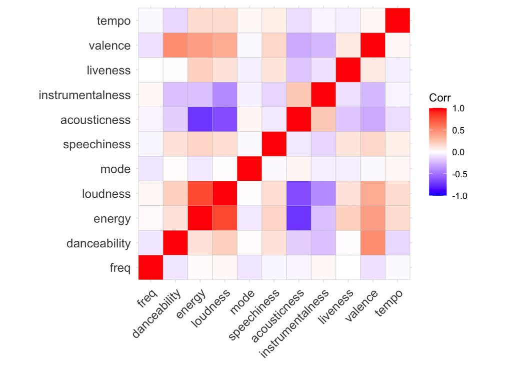

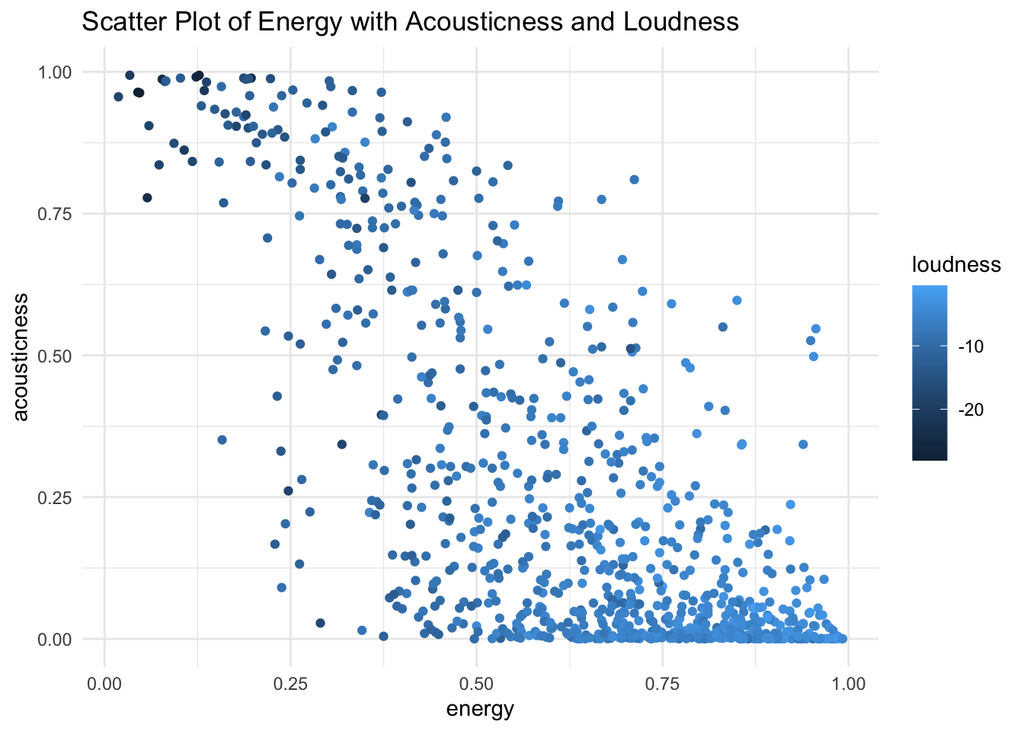

### Distribution

We are also interested in the music attribute distributions of my listening habit. First, we will use a `facet_grid` to plot multiple density charts of the attributes that have the range from `0.0` to `1.0`. From the charts below, I can find that:

- I generally prefer to listen to sad and moody songs - higher distribution of low valence compared to high valence.
- I generally listen to energetic songs.
- I don’t really listen to live music that much.
- I don’t really listen to acoustic songs that much.
- Most of the songs that I listen to have vocals.

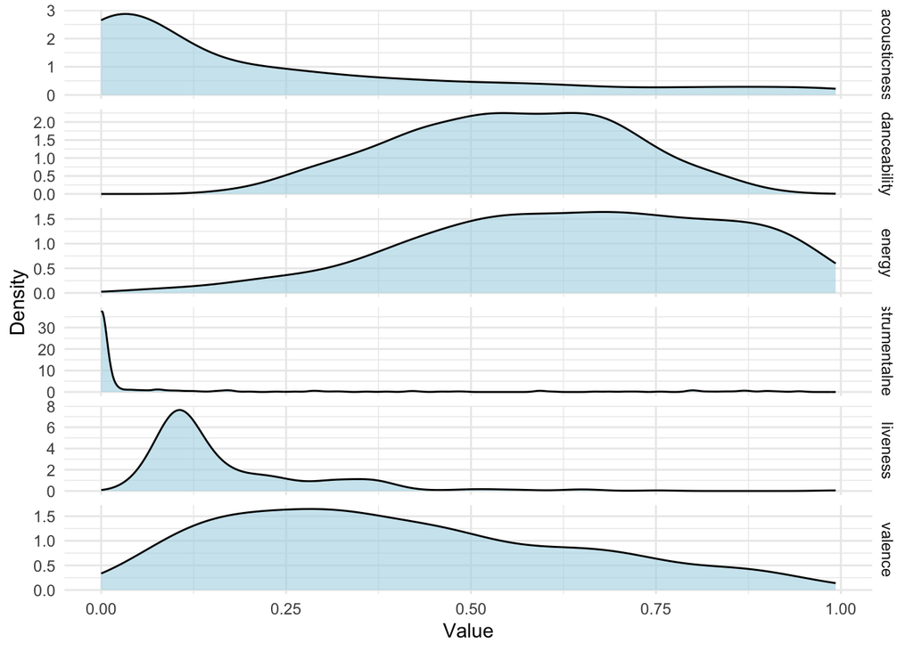

Other observations include:

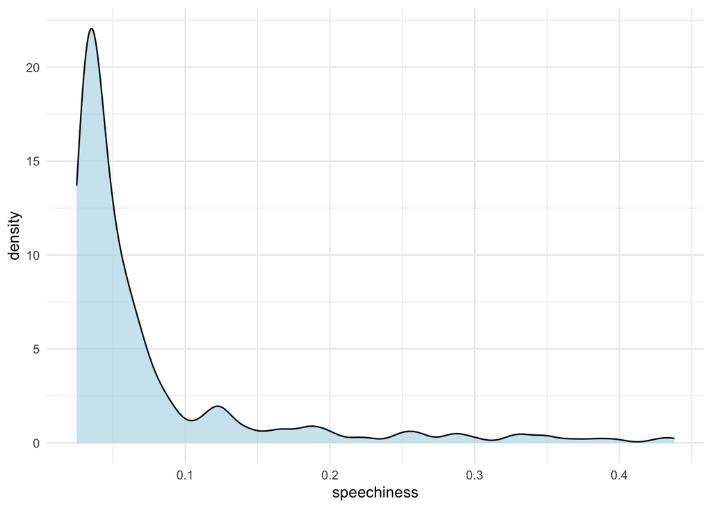

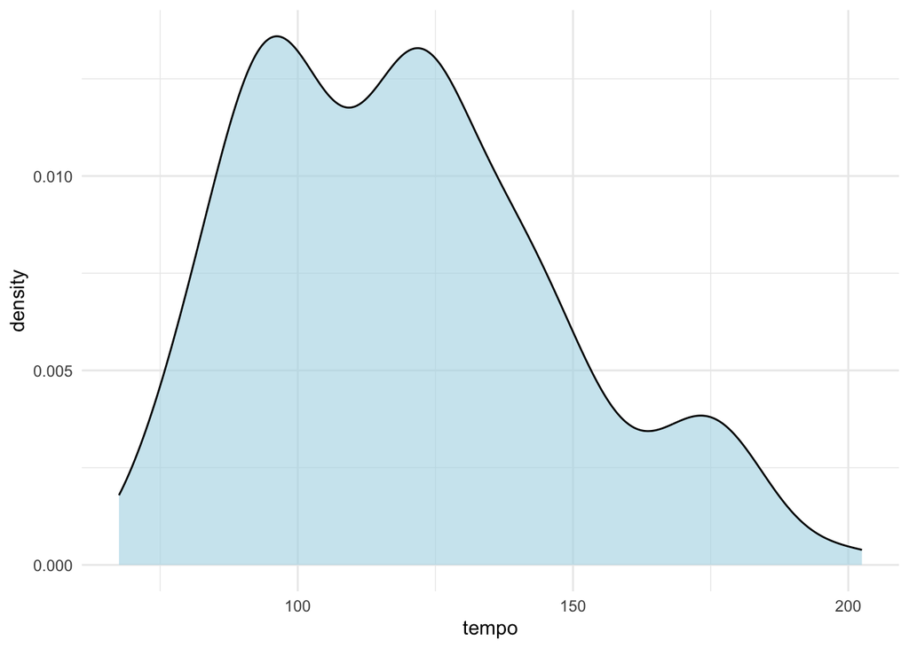

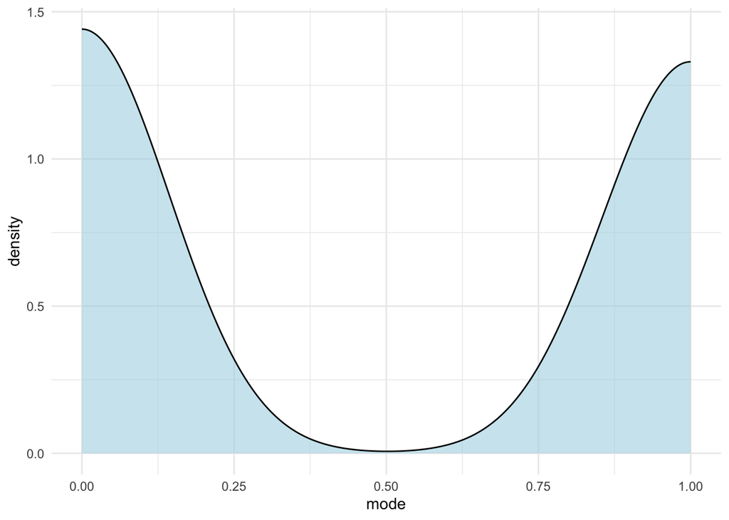

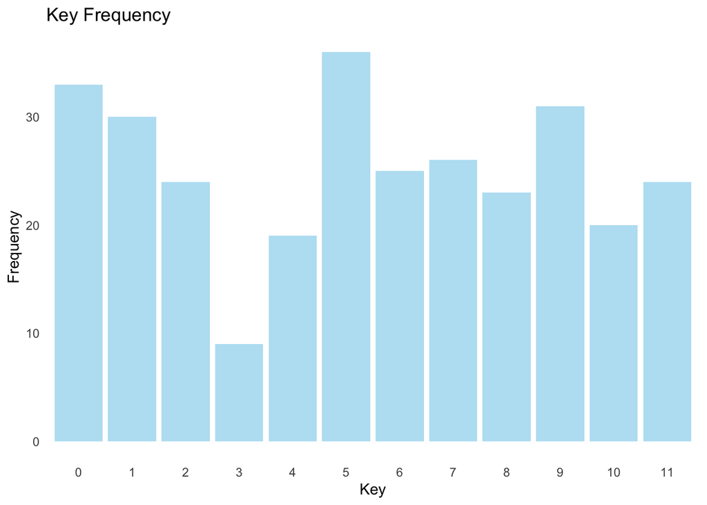

### Unsupervised Learning - Clustering

Since I do not have the `genre` tags from my streaming history dataset, I will manually label the genres by conducting clustering analysis based on the attributes. Since `key` is categorical, we will remove that to perform the clustering.

```
##                  dncbl enrgy ldnss spchn acstc instr lvnss valnc tempo
## danceability      1.00
## energy            0.12  1.00
## loudness          0.20  0.78  1.00
## speechiness       0.12  0.18  0.14  1.00
## acousticness     -0.16 -0.73 -0.64 -0.07  1.00
## instrumentalness -0.21 -0.21 -0.41 -0.14  0.23  1.00
## liveness         -0.01  0.20  0.12  0.11 -0.19 -0.10  1.00
## valence           0.49  0.42  0.36  0.17 -0.29 -0.24  0.09  1.00
## tempo            -0.13  0.15  0.15  0.07 -0.11 -0.04 -0.05  0.03  1.00
```

I will use the `scale()` function to normalize the values.

```r
# normalize data
x6 <- scale(x3_)
kable(headTail(x6)) %>%
  kable_styling(latex_options = "striped")
```

|  | danceability | energy | loudness | speechiness | acousticness | instrumentalness | liveness | valence | tempo |
| --- | --- | --- | --- | --- | --- | --- | --- | --- | --- |
| 1 | -0.57 | -0.76 | -0.17 | -0.61 | 0.39 | -0.43 | 1.29 | -0.97 | 0.39 |
| 2 | -0.98 | 0.41 | 0.61 | -0.33 | -0.84 | -0.41 | 0.28 | -1.34 | 0.33 |
| 3 | 1.08 | 0.28 | 0.49 | -0.41 | -0.63 | -0.44 | -0.54 | -0.45 | -0.09 |
| 4 | -0.55 | 0.76 | 1.11 | -0.53 | 0.37 | -0.44 | -0.33 | -0.86 | -0.22 |
| … | … | … | … | … | … | … | … | … | … |
| 868 | 1.43 | -0.43 | 0.27 | -0.05 | 0.24 | -0.44 | -0.83 | 0.91 | 0.48 |
| 869 | -0.25 | 0.04 | 0.04 | -0.5 | -0.28 | -0.43 | 2.81 | -0.38 | 0.41 |
| 870 | 0.52 | -1.16 | -0.57 | -0.26 | 1.79 | -0.44 | -0.64 | -1.43 | 0.15 |
| 871 | -1.33 | 1.56 | 1.35 | 1.09 | -0.84 | -0.44 | -0.21 | 0.09 | 2.4 |

Next, I will run the Gap Statistic to determine the most optimal number of clusters to be used for the dataset. The Gap Statistic finds that the k value consistently increases as the number of clusters increases until when `k = 9`. **We will use 9 as the number of clusters** as it gives the highest value of `k`.

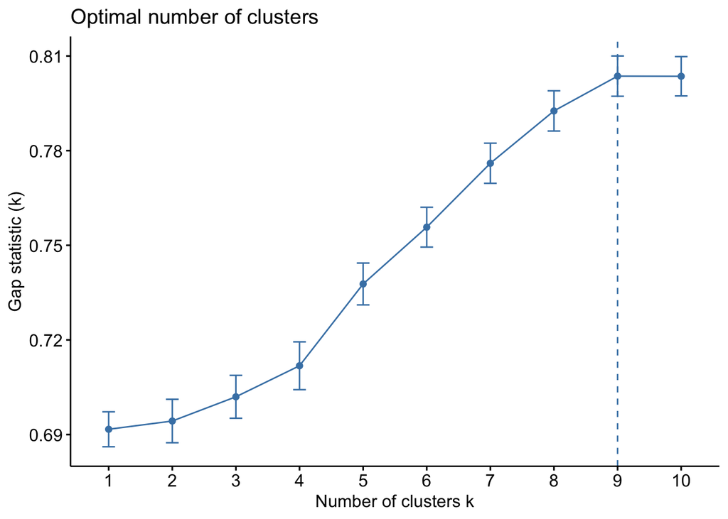

#### K-Means

I will use K-Means algorithm to perform the clustering, having defined the cluster `k = 9`

```r
set.seed(55)
k_cl <- kmeans(x6,9,nstart=25)
k_cl
```

Mapping of clusters on a 2-Dimensional graph.

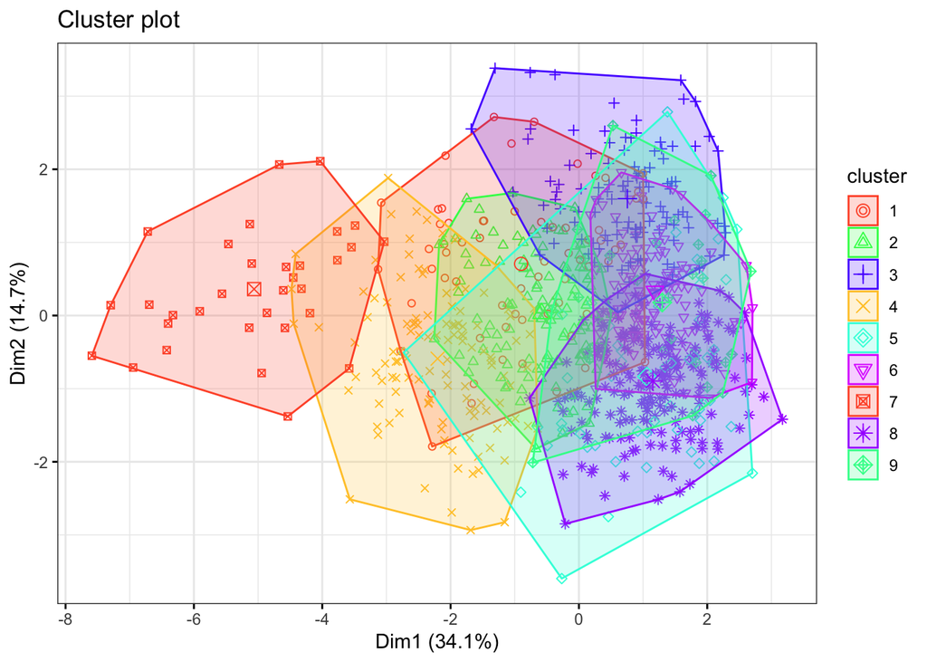

Let’s look at the number of tracks belonging to each cluster.

| Var1 | Freq |
| --- | --- |
| 1 | 64 |
| 2 | 131 |
| 3 | 118 |
| 4 | 120 |
| 5 | 56 |
| 6 | 122 |
| 7 | 32 |
| 8 | 198 |
| 9 | 30 |

To understand each of the cluster better, I want to check what songs belong to which cluster. I will append the song information with the clustering result from the K-Means, together with the listening frequency for all of the songs.

| trackName | artistName | cluster | freq |
| --- | --- | --- | --- |
| When the Sun Hits | Slowdive | 1 | 58 |
| Weird Fishes/ Arpeggi | Radiohead | 1 | 54 |
| Spectre | Radiohead | 1 | 34 |
| Sweet | Cigarettes After Sex | 1 | 25 |
| NA | NA | … | … |
| The Violence | Asking Alexandria | 9 | 1 |
| Viva La Vida - Live from Spotify London | Coldplay | 9 | 1 |
| Winter Wonderland | Leona Lewis | 9 | 1 |
| sinew | Purity Ring | 9 | 1 |

Let’s look at the cluster centers for each of the song attribute.

| cluster | danceability | energy | loudness | speechiness | acousticness | instrumentalness | liveness | valence | tempo |
| --- | --- | --- | --- | --- | --- | --- | --- | --- | --- |
| 1 | -0.1299626 | 0.1219869 | -0.2085161 | -0.2785330 | -0.2179679 | 2.4927592 | -0.3458345 | -0.3521443 | -0.0516031 |
| 2 | -0.1222235 | -0.4452913 | -0.1702216 | -0.3847775 | -0.1572427 | -0.3038624 | -0.2256092 | -0.7234073 | -0.5319622 |
| 3 | -0.7938341 | 0.6164709 | 0.5101176 | -0.0582194 | -0.5990766 | -0.3450470 | -0.0625386 | -0.2823504 | 1.4434993 |
| 4 | -0.2561859 | -1.3471815 | -0.9253777 | -0.3515334 | 1.6668367 | -0.2691130 | -0.4024001 | -0.6145545 | -0.1876796 |
| 5 | 0.3739930 | 0.1989231 | 0.2306517 | 3.0820842 | 0.0001598 | -0.3565640 | -0.0089868 | 0.4316999 | 0.0821129 |
| 6 | -0.1085830 | 0.8931936 | 0.7358677 | -0.1500982 | -0.6735847 | -0.3117111 | 0.4042581 | 0.0847861 | -0.4990966 |
| 7 | -1.3559605 | -2.0191720 | -2.8972783 | -0.4812925 | 2.1459318 | 2.8346980 | -0.3285355 | -1.2386945 | -0.1384740 |
| 8 | 0.9113701 | 0.3527288 | 0.3559463 | -0.1560874 | -0.3263779 | -0.3630612 | -0.2104625 | 1.1396237 | -0.0071864 |
| 9 | 0.1328856 | 0.4702698 | 0.2012896 | 0.3102602 | -0.5553080 | -0.2516463 | 3.6908090 | 0.1280368 | -0.4225401 |

Next, we can visualize them with a dodged bar plot. Immediately we can summarize the characteristics of each cluster.

- Cluster 1: sad and moody, ambient and atmospheric, lack of vocals. **Ambient/Instrumental Soundscapes**
- Cluster 2: very somber songs, with slow beats. perfect to chill with. **Atmospheric Downtempo**
- Cluster 3: energetic and loud but not really for dancing. **High-Energy Rock/Alternative**
- Cluster 4: slow songs and probably emotional songs. **Acoustic Ballads**
- Cluster 5: rap or fast vocals. **Fast-Paced Rap/Energetic**
- Cluster 6: very high energy and loud songs, with positive valence - good for exercise/active listening. **High-Energy Electronic/Dance**
- Cluster 7: high `acousticness` and `instrumentalness`, slow and sad mood, a lot of piano/guitar, calm. **Solo Piano/Instrumental**
- Cluster 8: very danceable and positive, summer songs. **Dance-Pop/Upbeat**
- Cluster 9: live/orchestra in the recordings. **Live Concert Recordings**

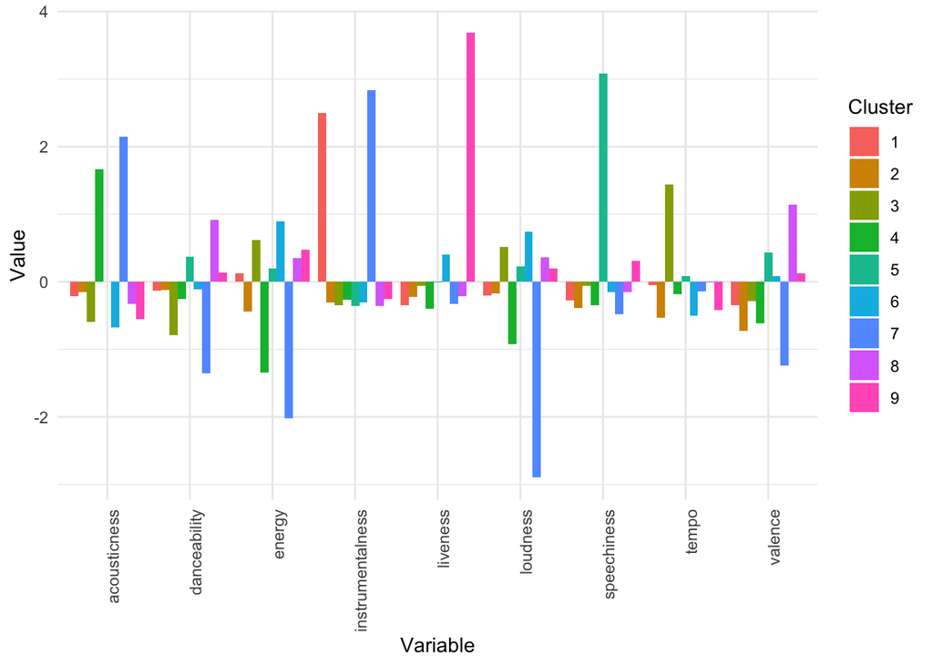

```r
x10 <- kmeans_centres %>%
  pivot_longer(cols = -cluster,
               names_to = "Variable",
               values_to = "Value")

x10$cluster <- as.factor(x10$cluster)

ggplot(x10, aes(x = Variable, y = Value, fill = cluster)) +
  geom_bar(stat = "identity", position = "dodge") +
  labs(x = "Variable", y = "Value", fill = "Cluster") +
  theme_minimal() +
  theme(axis.text.x = element_text(angle = 90, hjust = 1))
```

#### Use Polar Plot

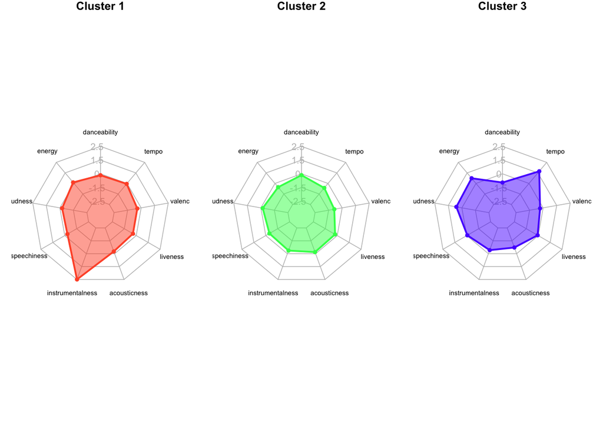

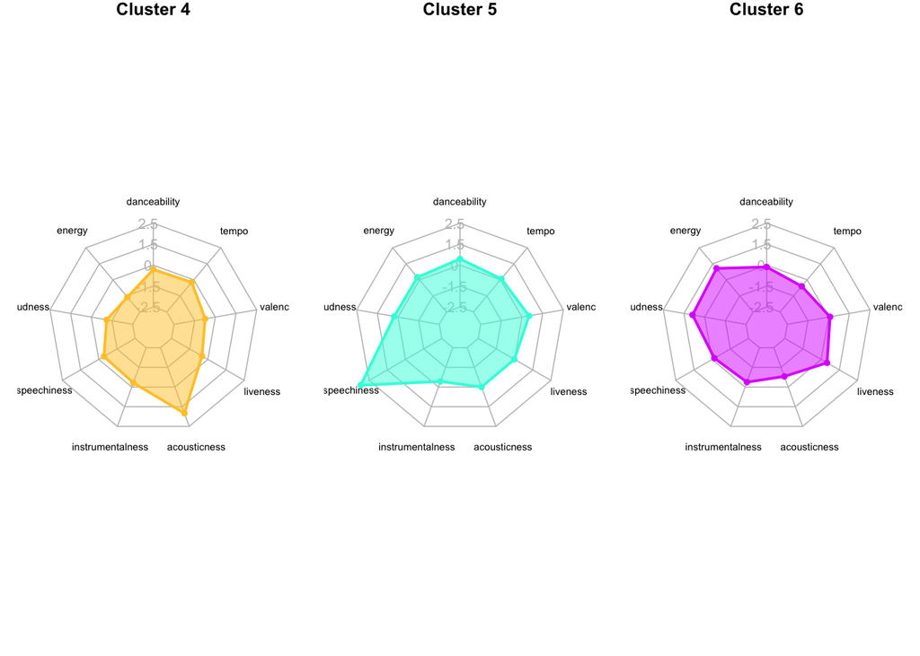

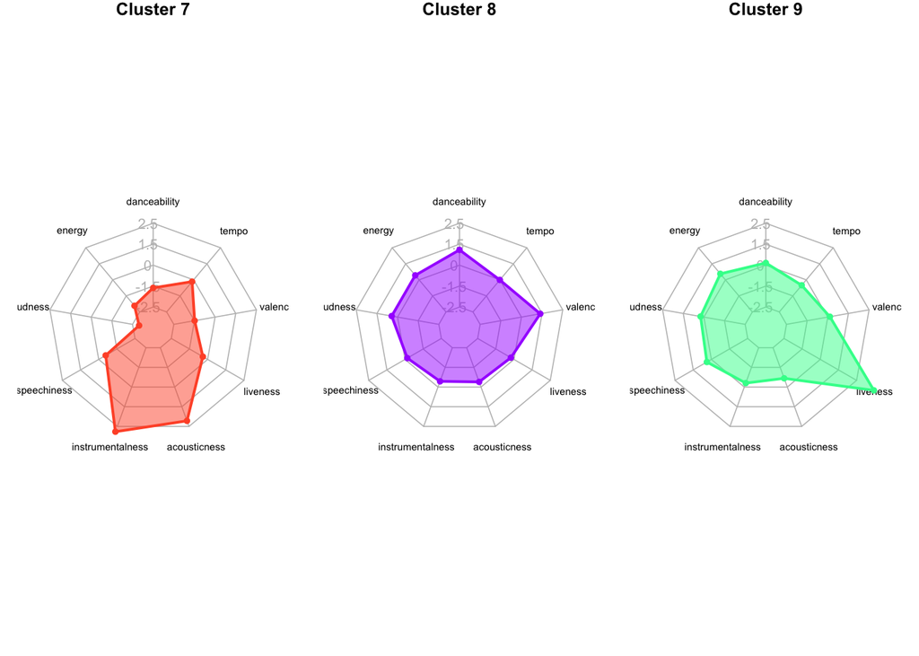

| id | dance-pop | atmospheric-downtempo | upbeat | alt-rock | rap | ballads | ambient | live | acoustic |
| --- | --- | --- | --- | --- | --- | --- | --- | --- | --- |
| 1 | Toxicity - System Of A Down | Take Me Out - Franz Ferdinand | Under The Influence - Chris Brown | Thought Contagion - Muse | No Role Modelz - J. Cole | Wasteland, Baby! - Hozier | When the Sun Hits - Slowdive | Mequetrefe - Arca | Suspirium - Thom Yorke |
| 2 | The Prince - Madeon | Still Don’t Know My Name - Labrinth | You’re So Dark - Arctic Monkeys | Yellow - Coldplay | So Good - B.o.B | We All Knew - Labrinth | Weird Fishes/ Arpeggi - Radiohead | Madness - Live at Rome Olympic Stadium - Muse | Je te laisserai des mots - Patrick Watson |
| 3 | Why Are Sundays So Depressing - The Strokes | Wait - M83 | You Only Live Once - The Strokes | The Adults Are Talking - The Strokes | tell me it’s okay - gnash | The Game of Love - Daft Punk | Spectre - Radiohead | Waiting for the End - Linkin Park | Unmade - Thom Yorke |
| 4 | Want To - Dua Lipa | Void - The Neighbourhood | Young Dumb & Broke - Khalid | When The Sun Goes Down - Arctic Monkeys | Pony - Ginuwine | Take Me Home, Country Roads - John Denver | Sweet - Cigarettes After Sex | Numb - Linkin Park | Sit Down Beside Me - Patrick Watson |
| 5 | W.D.Y.W.F.M? - The Neighbourhood | Who Will Save You Now - Les Friction | Why’d You Only Call Me When You’re High? - Arctic Monkeys | Unstoppable - Sia | Roaring 20s - Panic! At The Disco | The Heart of Life - John Mayer | While We Sleep - Insomnium | Stronger - Kanye West | Interlude 2 - Poppy |
| 6 | Water Under the Bridge - Adele | The Weekend - SZA | Uptown Girl - Radio Edit - Westlife | Wrong Side of Heaven - Five Finger Death Punch | The Magic - Macklemore | Test Me - The xx | Sunsetz - Cigarettes After Sex | Jewel - Flume | Perfect - The Piano Guys |
| 7 | Touch - Little Mix | Summertime Magic - Childish Gambino | Voices - Hurts | Time of Dying - Three Days Grace | White Privilege - Macklemore | The Ultracheese - Arctic Monkeys | Sail - AWOLNATION | Riquiquí - Arca | Dr. Ford - Ramin Djawadi |
| 8 | You Get Me So High - The Neighbourhood | Total Eclipse of the Heart - Bonnie Tyler | Water - Kehlani | You Found Me - The Fray | SICKO MODE - Travis Scott | This Is a Call - Les Friction | Syrups - Foals | Ideas - Au/Ra | Mi Amor - Daniel Pemberton |
| 9 | Zombie - Bad Wolves | verbatim - blackbear | Whenever, Wherever - Shakira | Suffer - Hurts | slide thru (feat. Jerry Good) - blackbear | Where’s My Love - Acoustic - SYML | Ushas - E.S. Posthumus | Killing Me Softly With His Song - Fugees | Quarantine - Justin Hurwitz |
| 10 | Unholy Confessions - Avenged Sevenfold | Toxic - Kehlani | where was u? - blackbear | Take on Me - a-ha | No Way - Fifth Harmony | You Are Not Alone - Michael Jackson | Resurrections - Lena Raine | Love Don’t Cost a Thing - Jennifer Lopez | Stars Will Fall - Duster |
| 11 | Welcome to the Black Parade - My Chemical Romance | uhgood - RM | Vultures - John Mayer | Write On Me - Fifth Harmony | Nonbinary - Arca | You’re Somebody Else - flora cash | Scary Monsters and Nice Sprites - Skrillex | Love On Top - Beyoncé | Death and I - Darren Korb |
| 12 | Woman Woman - AWOLNATION | Straight for the Knife - Sia | WHISTLE - BLACKPINK | Suite-Pee - System Of A Down | Pass That Dutch - Missy Elliott | Your World Will Fail - Les Friction | Symphonia IX (My Wait Is U) - Grimes | Orphans - Coldplay | Dragonstone - Ramin Djawadi |
| 13 | The Suburbs - Arcade Fire | Stranger Tings - RINI | What a Girl Wants - Christina Aguilera | That’s My Girl - Fifth Harmony | Penis Song - Macklemore | Two Weeks in December - Skullcrusher | Scattered and Lost - Lena Raine | Remember When - Wallows | Everest - All Them Witches |
| 14 | Touch off - UVERworld | Streets - Doja Cat | White Sky - Vampire Weekend | The Catalyst - Linkin Park | Plain Jane - A$AP Ferg | When I R.I.P. - Labrinth | She - Harry Styles | Roll Call - The Neighbourhood | Final Expense - Darren Korb |
| 15 | Up&Up - Coldplay | THE NEWS - PARTYNEXTDOOR | You’ll miss me when I’m not around - Grimes | The Holy Mountain - Poppy | Show & Tell - Melanie Martinez | Will He - Joji | Skin - Grimes | Sorrows - Bryson Tiller | Karl - M83 |
| 16 | Walk Away - Franz Ferdinand | To Be Mine - MARUV | Unwritten - Natasha Bedingfield | Together - Sia | Soldiers - Macklemore | tokyo - RM | Snakes - Sorry | The Box - Roddy Ricch | No Quarter - Remaster - Led Zeppelin |
| 17 | Washing Machine Heart - Mitski | To Me - Alina Baraz | Vowels = space and time - Grimes | Use Somebody - Kings of Leon | Sorry Not Sorry - Demi Lovato | The A Team - Ed Sheeran | The Antichrist - Slayer | The Violence - Asking Alexandria | Philosophy of Time Travel - Michael Andrews |
| 18 | We Can’t Stop - Miley Cyrus | Watch Your Mouth - The Backseat Lovers | What the Hell - Avril Lavigne | Vanishing Point - Alexandra Savior | Vibe (If I Back It Up) - Cookiee Kawaii | Vacation - RINI | The Painful Way - Darren Korb | Viva La Vida - Live from Spotify London - Coldplay | The Mission / How Great Thou Art - The Piano Guys |
| 19 | Why - Dominic Fike | White Flag - Daughtry | Wheels on the Bus - Melanie Martinez | White Flag - Dido | WTF Are We Talking For - Labrinth | Within - Daft Punk | Truly - Cigarettes After Sex | Winter Wonderland - Leona Lewis | The Theory of Everything - Jóhann Jóhannsson |
| 20 | X - Poppy | Your Voice - Les Friction | XS - Rina Sawayama | 乱舞のメロディ - SID | You Got It - Vedo | you broke me first - Tate McRae | Wall Fuck - Flume | sinew - Purity Ring | Thermometer - Poppy |

Get the frequency and seconds played of each cluster to understand listening habits

```r
x9
```

```
## # A tibble: 871 × 4
## # Groups:   trackName [864]
##    trackName                 artistName           cluster  freq
##    <chr>                     <chr>                <fct>   <int>
##  1 When the Sun Hits         Slowdive             ambient    58
##  2 Weird Fishes/ Arpeggi     Radiohead            ambient    54
##  3 Spectre                   Radiohead            ambient    34
##  4 Sweet                     Cigarettes After Sex ambient    25
##  5 My Name is Dark - Art Mix Grimes               ambient    23
##  6 Breathe                   The Prodigy          ambient    22
##  7 Forever                   Labrinth             ambient    21
##  8 Ingenue                   Atoms For Peace      ambient    21
##  9 While We Sleep            Insomnium            ambient    11
## 10 Inhaler                   Foals                ambient     7
## # ℹ 861 more rows
```

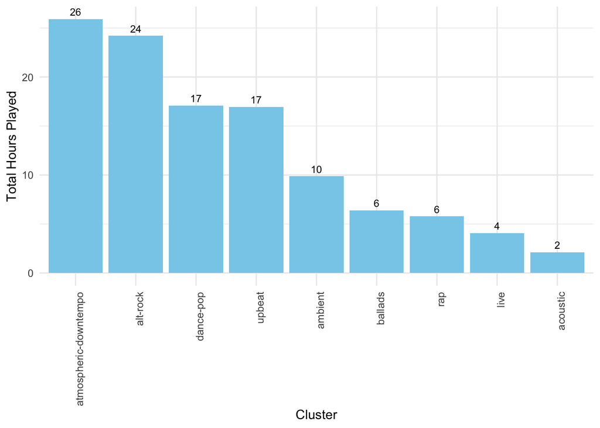

```r
x12 <- left_join(master.data, x9, by = c("trackName", "artistName"))
x12 <- na.omit(x12)

x13 <- x12 %>%
  group_by(cluster) %>%
  summarise(totalPlayed = sum(seconds), freq = n()) %>%
  mutate(cluster = as.factor(cluster))

ggplot(x13, aes(x = reorder(cluster, -totalPlayed), y = totalPlayed/3600)) + geom_bar(stat = 'identity', fill = 'skyblue') + theme_minimal() + labs(x = "Cluster", y = "Total Hours Played") + geom_text(aes(label = round(totalPlayed/3600, 0)), vjust = -0.5, size = 3) + theme(axis.text.x = element_text(angle = 90, hjust = 1))
```

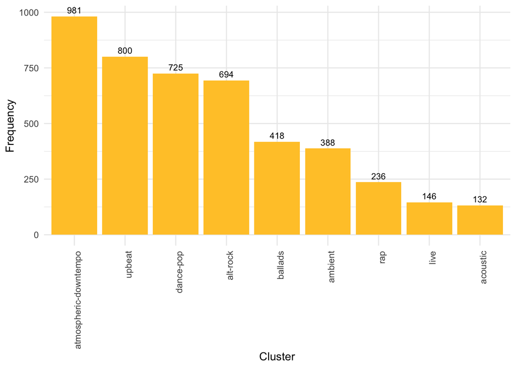

```r
ggplot(x13, aes(x = reorder(cluster, -freq), y = freq)) + geom_bar(stat = 'identity', fill = '#FFC733') + theme_minimal() + labs(x = "Cluster", y = "Frequency") + geom_text(aes(label = round(freq, 0)), vjust = -0.5, size = 3) + theme(axis.text.x = element_text(angle = 90, hjust = 1))
```

Get frequency by month

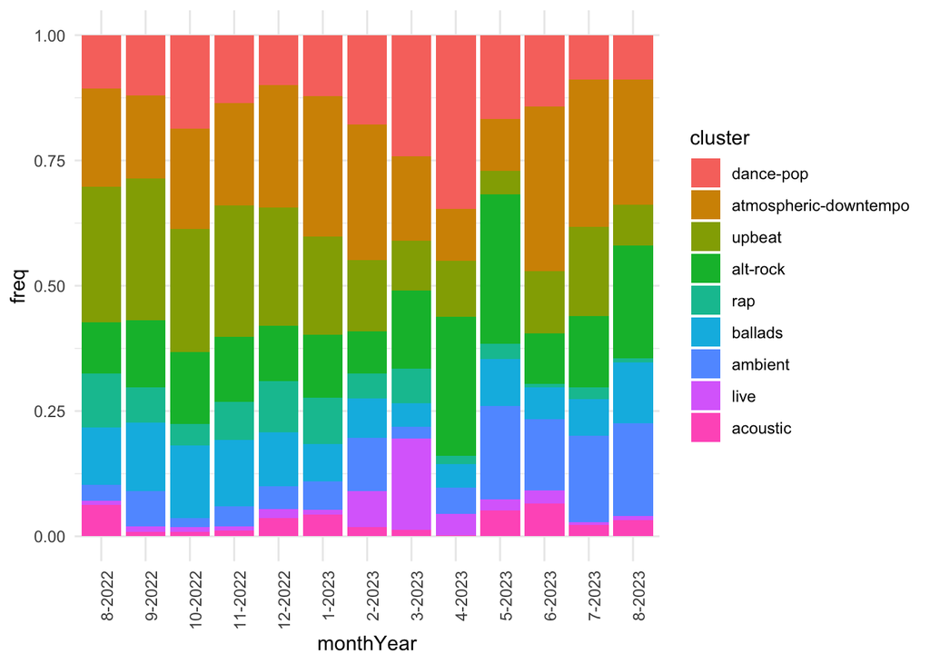

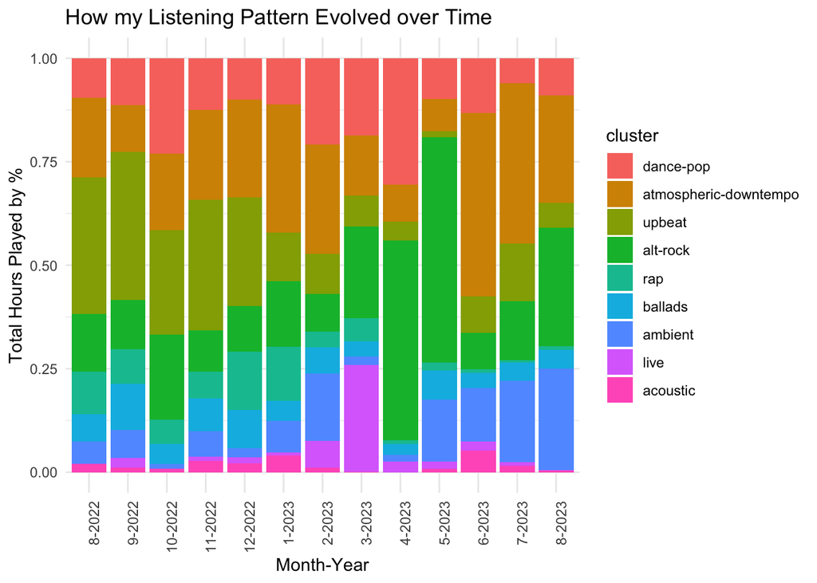